# 2018201711-何辰轩-第十二周作业

# 新教材5.1

- 在一个有3个主要大型商场的商贸中心，调查479个不同年龄的人首先去3个商场中的哪一个，结果如下所示.

```r
# 数据读入
data_5.1 <- matrix(c(83, 70, 45, 91, 86, 15, 41, 38, 10),
                   byrow = TRUE,
                   nrow = 3,
                   ncol = 3,
                   dimnames = list("年龄段" = c("<=30", "30~50", ">50"),
                                   "商场" = c("商场1", "商场2", "商场3")))
data_5.1
```

```
       商场
年龄段  商场1 商场2 商场3
  <=30     83    70    45
  30~50    91    86    15
  >50      41    38    10
```

- 问题：不同年龄段人对各商场的购物倾向性是否存在差异？
- 使用$\chi^2$齐性检验进行检验：
  - 建立假设检验问题为

$$\forall i=1,2,3\\ \quad H_0:p_{i1}=p_{i2}=p_{i3}=p_i\quad v.s. \quad H_1:等式不全成立$$

```r
# chisq.test进行卡方齐性检验
chisq.test(data_5.1)
```

```
    Pearson's Chi-squared test

data:  data_5.1
X-squared = 18.651, df = 4, p-value = 0.0009203
```

- 根据$\chi^2$检验，发现$p=0.0009<\alpha=0.05$，故而拒绝原假设，认为不同年龄段的人对各商场的购物倾向性存在显著差异。

# 新教材5.2

- 美国某总统选举前，由社会调查总部抽查黑白种族与支持不同政党是否有关，得到数据如下.

```r
# 导入数据
data_5.2 <- matrix(c(341, 405, 105, 103, 11, 15),
                   byrow = TRUE,
                   nrow = 2,
                   dimnames = list("种族" = c("白人", "黑人"), "政党"= c("民主党", "共和党", "无党")))
data_5.2
```

```
      政党
种族   民主党 共和党 无党
  白人    341    405  105
  黑人    103     11   15
```

- 问：不同种族与所支持的政党之间是否存在独立性？
- 使用$\chi^2$齐性检验进行检验：
  - 建立假设检验问题为

$$\forall i=1,2\\ \quad H_0:p_{i1}=p_{i2}=p_i\quad v.s. \quad H_1:等式不全成立$$

```r
# chisq.test进行卡方齐性检验
chisq.test(data_5.2)
```

```
    Pearson's Chi-squared test

data:  data_5.2
X-squared = 79.431, df = 2, p-value < 2.2e-16
```

- 根据$\chi^2$检验，发现$p=2.2*10^{-16}<\alpha=0.05$，故而应该拒绝原假设，即我们有充分证据认为不同种族与所支持的政党之间不独立，有相关关系。

# 新教材5.3

- 下面是一个医学例子，研究某类肺炎患者和以前是否曾经患过该类肺炎之间的疾病继承性关系，下面是30个人按照当前患某类肺炎和曾经患某类肺炎之间的2×2分类表.

```r
# 导入数据
# 书上行名与列名相同，应该是笔误
# 取行为当前是否患某类肺炎
data_5.3 <- matrix(c(6, 4, 1, 19),
                   byrow = TRUE,
                   nrow = 2,
                   dimnames = list("以前是否患过某类肺炎" = c("是", "否"), "当前是否患某类肺炎"= c("是", "否")))
data_5.3
```

```
                    当前是否患某类肺炎
以前是否患过某类肺炎 是 否
                  是  6  4
                  否  1 19
```

- 在这个问题中，某些类别的例数较少，故而一般的$\chi^2$检验不适用，只能采用$Fisher$精确性检验.

```r
# 使用fisher.test进行检验
fisher.test(data_5.3)
```

```
    Fisher's Exact Test for Count Data

data:  data_5.3
p-value = 0.002122
alternative hypothesis: true odds ratio is not equal to 1
95 percent confidence interval:
    2.152514 1362.408171
sample estimates:
odds ratio
   24.2696
```

- 根据$Fisher$精确性检验，发现$p=0.0021<\alpha=0.05$，故而应该拒绝原假设，即我们可以认为以前是否患过某类肺炎与现在是否患肺炎存在一定的继承性关系。

# 新教材5.4

- 对479个不同年龄段的人调查他们对各种不同类型电视节目的喜爱情况，要求每人只能选出他们最喜欢观看的电视节目类型，结果如下.

```r
# 导入数据
data_5.4 <- matrix(c(83, 70, 45, 91, 86, 15, 41, 38, 10),
                   nrow = 3,
                   dimnames = list("年龄段" = c("<=30", "31~50", ">50"), "节目类型"= c("体育类1", "电视剧类2", "综艺类3")))
data_5.4
```

```
       节目类型
年龄段  体育类1 电视剧类2 综艺类3
  <=30       83        91      41
  31~50      70        86      38
  >50        45        15      10
```

- 问：不同观众对三类节目的关注率是否一样？
- 使用$\chi^2$齐性检验进行检验：
  - （事实上，此题的数据与5.1题的数据完全相同）
  - 建立假设检验问题为

$$\forall i=1,2,3\\ \quad H_0:p_{i1}=p_{i2}=p_{i3}=p_i\quad v.s. \quad H_1:等式不全成立$$

```r
# 调用函数进行卡方检验
chisq.test(data_5.4)
```

```
    Pearson's Chi-squared test

data:  data_5.4
X-squared = 18.651, df = 4, p-value = 0.0009203
```

- 根据$\chi^2$检验，发现$p=0.0009<\alpha=0.05$，故而应该拒绝原假设，即我们可以认为不同观众对三类节目的关注率不一样。

# 新教材5.7

- 对于三类不同学校，分别考察学生家庭经济状况与其高考成绩之间的关系，用经济状况好（A）与经济状况一般（B），对比记录其结果，如下.

```r
# 导入数据
data_5.7.1 <- matrix(c(43, 65, 87, 77),
                     byrow = TRUE,
                     nrow = 2,
                     dimnames = list("经济状况" = c("A", "B"),
                                     "高考情况"= c("一类学校", "二类学校")))
data_5.7.2 <- matrix(c(9, 73, 15, 30),
                     byrow = TRUE,
                     nrow = 2,
                     dimnames = list("经济状况" = c("A", "B"),
                                     "高考情况"= c("一类学校", "二类学校")))
data_5.7.3 <- matrix(c(7, 18, 9, 11),
                     byrow = TRUE,
                     nrow = 2,
                     dimnames = list("经济状况" = c("A", "B"),
                                     "高考情况"= c("一类学校", "二类学校")))
```

- 不同的学校代表不同的层，层与层之间的情况存在一定的差别，故而需要使用$Mantel-Haenszel$检验

```r
# 整合上述数据
data_5.7 <- c(data_5.7.1, data_5.7.2, data_5.7.3)
x <- array(data_5.7, c(2, 2, 3))
# 调用函数进行mantelhaen检验
mantelhaen.test(x)
```

```
    Mantel-Haenszel chi-squared test with continuity correction

data:  x
Mantel-Haenszel X-squared = 11.638, df = 1, p-value = 0.0006461
alternative hypothesis: true common odds ratio is not equal to 1
95 percent confidence interval:
 0.3222519 0.7298350
sample estimates:
common odds ratio
        0.4849646
```

# 案例与讨论2

```r
# 读入数据
data <- read.csv("D:\\me\\Statistics\\NonparametricStatistics\\Nonparametric-Statistics\\Data\\birth_weight.csv", header = TRUE)
```

- 研讨问题与后续讨论如下：

## 研讨问题1

- 定义低体重出生婴儿为$2500g$以下，请绘图刻画未婚黑人母亲的婴儿出生体重经验分布的点估计和置信区间估计（置信度$90\%$），并从图上观察判断婴儿低体重和母亲婚姻状况之间的关系
- 首先由DKW不等式：
  $$\forall\varepsilon>0,\\
  P(\sup\limits_x|\hat F_n(x)-F(x)|>\varepsilon)\le 2e^{-2n\varepsilon^2}$$
- 可以得到：
  $$令：L(x)=max\{F_n(x)-\varepsilon_n,0\}\quad
  U(x)=min\{F_n(x)+\varepsilon_n,1\}\\
  其中，\varepsilon_n=\sqrt{\frac{1}{2n}ln\frac{2}{\alpha}}\\
  则有：P(L(x)\le F(x)\le U(x))\ge 1-\alpha$$
- 由此绘制经验分布及其置信区间

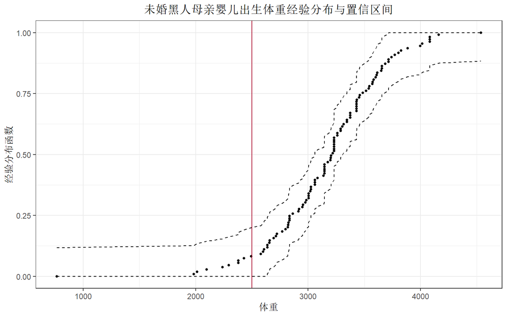

```r
alpha <- 0.1 # 显著性水平
data.black.unmarried <- data[which(data$black == 1 & data$married == 0),] # 选出黑人未婚母亲的数据
weight.sort <- data.black.unmarried[order(data.black.unmarried$weight),] # 对体重进行排序
size <- length(weight.sort$weight) # 获取数目
weight.sort$ecd <- seq(0, 1, length.out = size) # 获取经验分布函数值
epsilon <- sqrt(1/2/size*log(2/alpha)) # DKW不等式中的epsilon
weight.sort$ecd.upper <- mapply(min, weight.sort$ecd + epsilon , 1) # 置信上界
weight.sort$ecd.lower <- mapply(max, weight.sort$ecd - epsilon , 0) # 置信下界
p <- ggplot(aes(x = weight), data = weight.sort) +
  geom_point(aes(y = ecd), size = 1) + # 经验分布函数
  geom_line(aes(y = ecd.lower), lty = 2) + # 置信下界
  geom_line(aes(y = ecd.upper), lty = 2) + # 置信上界
  geom_vline(aes(xintercept = 2500), color = I("#ad0b2c")) + # 低体重分割线
  theme_bw() + # 改变主题
  labs(title = "未婚黑人母亲婴儿出生体重经验分布与置信区间") + # 加入标题
  ylab("经验分布函数") +
  xlab("体重") +
  theme(plot.title = element_text(hjust = 0.5)) # 标题居中
print(p)
```

- 由图中可以看到，在低体重界限下（2500g），存在一定数量的低体重值，而且低体重的置信上限达到了$20\%$，而与之形成鲜明对比的是，世界的整体水平，其低体重的置信上限低于$10\%$，故而可以初步判断，未婚母亲的婴儿体重可能更偏低一些，这也符合我们的常识

## 研讨问题2

- 用泊松回归模型探究黑人母亲、母亲怀孕期间增加体重与低体重婴儿之间的关系

```r
# 将母亲孕期体重的变化转为分类数据
data$classified[data$m.wtgain>-50 & data$m.wtgain<=-20] <- "-50 - -20"
data$classified[data$m.wtgain>=-19 & data$m.wtgain<=-10] <- "-19 - -10"
data$classified[data$m.wtgain>=-9 & data$m.wtgain<=0] <- "-9 - 0"
data$classified[data$m.wtgain>=1 & data$m.wtgain<=10] <- "1 - 10"
data$classified[data$m.wtgain>=11 & data$m.wtgain<=20] <- "11 - 20"
data$classified[data$m.wtgain>=21 & data$m.wtgain<=55] <- "21 - 55"
# 给定因子的排序，回归时，将"-50 - -20"作为基准组进行泊松回归
data$classified <- factor(data$classified,levels =
                            c("-50 - -20",
                              "-19 - -10",
                              "-9 - 0",
                              "1 - 10",
                              "11 - 20",
                              "21 - 55"))
# 给定01变量方便计数
data$LowAndBlack <- 0
data$LowAndBlack[data$black==1&data$weight<2500] <- 1
data$LowAndWhite <- 0
data$LowAndWhite[data$black==0&data$weight<2500] <- 1
# 生成新数据（分类计数数据）
data_new <- group_by(data,classified) %>%
  summarise(black = sum(black),
                   black_low = sum(LowAndBlack),
                   white = n()-sum(black),
                   white_low = sum(LowAndWhite))
# 进一步给出不同肤色的分类数据
dat <- data.frame(loss_weight=rep(data_new$classified,2),
                  black=c(rep(1,6),rep(0,6)),
                  total_number = c(data_new$black,data_new$white),
                  weight_low = c(data_new$black_low,data_new$white_low))
dat$black <- as.factor(dat$black)
# 进行泊松回归
res.weight <- glm(weight_low ~ loss_weight+black+offset(log(total_number)),
                  data = dat,
                  family = poisson)
summary(res.weight)
```

```
Call:
glm(formula = weight_low ~ loss_weight + black + offset(log(total_number)),
    family = poisson, data = dat)

Deviance Residuals:
       1         2         3         4         5         6         7         8
-0.37678   0.05534  -0.00003  -0.08945   0.10349   0.50079   0.27073  -0.03640
       9        10        11        12
 0.00002   0.04146  -0.07058  -0.37314

Coefficients:
                     Estimate Std. Error z value Pr(>|z|)
(Intercept)           -2.4460     0.3937  -6.213 5.19e-10 ***
loss_weight-19 - -10  -0.1238     0.4693  -0.264   0.7919
loss_weight-9 - 0     -0.4664     0.4371  -1.067   0.2860
loss_weight1 - 10     -1.4926     0.5591  -2.670   0.0076 **
loss_weight11 - 20    -0.5870     0.5566  -1.055   0.2916
loss_weight21 - 55    -0.9639     0.8021  -1.202   0.2295
black1                 0.5610     0.2984   1.880   0.0601 .
---
Signif. codes:  0 '***' 0.001 '**' 0.01 '*' 0.05 '.' 0.1 ' ' 1

(Dispersion parameter for poisson family taken to be 1)

    Null deviance: 16.95811  on 11  degrees of freedom
Residual deviance:  0.63508  on  5  degrees of freedom
AIC: 51.623

Number of Fisher Scoring iterations: 4
```

- 由泊松回归结果可知，黑人母亲出现较低体重婴儿的概率平均是白人母亲的$e^{0.5610}\approx 1.75$，且系数在置信度$10\%$下是显著的，可以看出黑人孕妇的营养状况亟需改善。
- 从体重看，孕妇体重增幅在$1-10$磅之间最佳，且系数显著。
- 同时，各类增重、减重相对对照组——减少$21-50$磅而言，婴儿体重偏低都低一些。不过我们也注意到，体重过高或过低均不利于婴儿的健康。

## 后续讨论1

- 尝试对母亲的受教育程度进行分析，并将其与母亲是否已婚纳入回归模型，做进一步的分析
- 数据中提供了母亲的教育水平是否是高中、是否是大学，故而我们将受教育程度分为三类：
  - 高中（High School）
  - 大学（College）
  - 非高中和大学
- 并以非高中和大学作为对照组。
- 婚姻状况则分为已婚和未婚
- 首先，我们对受教育程度进行泊松回归：

```r
# 对是否结婚和受教育程度进行分类计数
data_new_2 <- group_by(data, ed.hs, ed.col, married) %>%
  summarise(low = sum(LowAndBlack) + sum(LowAndWhite),
            total_number = n())
# 重新生成列：education_，保存母亲受教育程度的具体情况，分三类
data_new_2$education_ <- "not hs & not col"
data_new_2$education_[data_new_2$ed.hs == 1] <- "High School"
data_new_2$education_[data_new_2$ed.col == 1] <- "College"
data_new_2$education_ <- factor(data_new_2$education_,
                                levels = c("not hs & not col",
                                           "High School",
                                           "College"))

# 对受教育程度进行泊松回归
res.education <- glm(low ~ education_ + offset(log(total_number)),
                  data = data_new_2,
                  family = poisson)
summary(res.education)
```

```
Call:
glm(formula = low ~ education_ + offset(log(total_number)), family = poisson,
    data = data_new_2)

Deviance Residuals:
      1        2        3        4        5        6
 0.2492  -0.1949   1.8360  -0.6421   0.1562  -0.1264

Coefficients:
                      Estimate Std. Error z value Pr(>|z|)
(Intercept)           -2.81421    0.20000 -14.071   <2e-16 ***
education_High School -0.20478    0.31436  -0.651    0.515
education_College     -0.08043    0.34194  -0.235    0.814
---
Signif. codes:  0 '***' 0.001 '**' 0.01 '*' 0.05 '.' 0.1 ' ' 1

(Dispersion parameter for poisson family taken to be 1)

    Null deviance: 4.3532  on 5  degrees of freedom
Residual deviance: 3.9235  on 3  degrees of freedom
AIC: 33.751

Number of Fisher Scoring iterations: 5
```

- 由结果可知，相对于对照组（非高中和大学文凭）而言，拥有高中文凭、大学文凭的母亲，其婴儿低体重的概率均降低，不过系数均不显著。
- 之后，我们将婚姻状况纳入回归模型：

```r
# 加入婚姻状况（已婚为1）进行泊松回归
res.education.married <- glm(low ~ education_ + married + offset(log(total_number)),
                  data = data_new_2,
                  family = poisson)
summary(res.education.married)
```

```
Call:
glm(formula = low ~ education_ + married + offset(log(total_number)),
    family = poisson, data = data_new_2)

Deviance Residuals:
      1        2        3        4        5        6
-0.3219   0.2784   1.4920  -0.5670  -0.3088   0.2765

Coefficients:
                      Estimate Std. Error z value Pr(>|z|)
(Intercept)           -2.63428    0.25944 -10.154   <2e-16 ***
education_High School -0.21058    0.31442  -0.670    0.503
education_College      0.01992    0.35797   0.056    0.956
married               -0.30258    0.29622  -1.021    0.307
---
Signif. codes:  0 '***' 0.001 '**' 0.01 '*' 0.05 '.' 0.1 ' ' 1

(Dispersion parameter for poisson family taken to be 1)

    Null deviance: 4.3532  on 5  degrees of freedom
Residual deviance: 2.9004  on 2  degrees of freedom
AIC: 34.728

Number of Fisher Scoring iterations: 4
```

- 我们发现，加入婚姻状况以后，有大学文凭的母亲其婴儿低体重的概率还增加了，已婚的母亲相对未婚的母亲其婴儿低体重的概率降低。不过相关的系数均不显著。

## 后续讨论2

- 尝试使用对数线性模型进行分析，分析比较泊松回归于对数线性模型所得结果的异同
- 考虑对数线性模型的联合分布频率表：

  |  | 已婚 | 未婚 | 总和 |
  | --- | --- | --- | --- |
  | not hs & not col | 0.263 | 0.154 | 0.417 |
  | College | 0.220 | 0.015 | 0.235 |
  | High School | 0.213 | 0.135 | 0.348 |
  | 总和 | 0.696 | 0.304 | 1.000 |

- 进而获得联合分布概率$\frac{p_{ij}}{p_{i.}p_{.j}}$

  |  | 已婚 | 未婚 |
  | --- | --- | --- |
  | not hs & not col | 0.906 | 1.215 |
  | College | 1.345 | 0.210 |
  | High School | 0.879 | 1.276 |

```r
# 编制函数进行对数线性模型独立性检验
f <- function(x){
  df=x$df
  lrt=x$lrt
  p.lrt=1-pchisq(x$lrt,x$df)
  Q=x$pear
  p.pear=1-pchisq(x$pear,x$df)
  if(p.lrt<0.05|p.pear<0.05) conclusion="不独立"
  else conclusion="独立"
  list(df,lrt,p.lrt,Q,p.pear,conclusion)
}
A <- matrix(c(248, 144, 210, 12, 203, 128), nrow = 3, byrow = TRUE)
B <- matrix(c(15, 10, 10, 3, 10, 7), nrow = 3, byrow = TRUE)
n <- array(c(A,B),dim=c(3,2,2))
m1 <- loglin(n, list(1,2,3)) # 模型(x,y,z)
```

```
2 iterations: deviation 1.136868e-13
```

```r
f1 <- f(m1)
```

```r
# 加入交互项进行回归
res.education <- glm(low ~ education_ +
                       married +
                       education_*married +
                       offset(log(total_number)),
                  data = data_new_2,
                  family = poisson)
summary(res.education)
```

```
Call:
glm(formula = low ~ education_ + married + education_ * married +
    offset(log(total_number)), family = poisson, data = data_new_2)

Deviance Residuals:
[1]  0  0  0  0  0  0

Coefficients:
                              Estimate Std. Error z value Pr(>|z|)
(Intercept)                   -2.73437    0.31623  -8.647   <2e-16 ***
education_High School         -0.22500    0.49281  -0.457   0.6480
education_College              1.12493    0.65828   1.709   0.0875 .
married                       -0.12974    0.40825  -0.318   0.7506
education_High School:married  0.03039    0.63994   0.047   0.9621
education_College:married     -1.35187    0.77460  -1.745   0.0809 .
---
Signif. codes:  0 '***' 0.001 '**' 0.01 '*' 0.05 '.' 0.1 ' ' 1

(Dispersion parameter for poisson family taken to be 1)

    Null deviance:  4.3532e+00  on 5  degrees of freedom
Residual deviance: -4.4409e-16  on 0  degrees of freedom
AIC: 35.828

Number of Fisher Scoring iterations: 3
```

- 由于交互项的自由度只有2，故而输出多了两行，可以通过系数的加减获得其他组合的情况
- 注意到，加入交互项以后，受教育程度为大学，且婚姻状况为未婚的在$\alpha=0.1$的显著性水平下显著为正，即受教育程度为大学且未婚的母亲，他们的孩子可能更有可能出现低体重（为控制组的$e^{1.125}=3.08$倍）
- 另外，受教育程度为大学，且婚姻状况为已婚的在$\alpha=0.1$的显著性水平下显著为负，即受教育程度为大学且已婚的母亲，他们的孩子可能更有可能不出现低体重（为控制组的$e^{-1.352}=0.26$倍）
  - 这个解释符合常理，注意到受教育程度为大学，且未婚的人数非常少，说明教育程度越高，更倾向于形成一个稳定的家庭，而这些大学学历但未婚的女性，由于没有保护好自己，而且可能相对缺乏生活经验，所以婴儿出现低体重的概率更高
  - 而对于那些已婚且受教育程度为大学的母亲，他们拥有稳定的家庭，足够的能力，使得她们婴儿的低体重率显著低于其他组别的母亲。